# Coverage of the confidence intervals of goric_CI()

A simulation study for the GORICA values, differences, weights, and ratios of weights

restriktor

2026-10-23

# 1 Aim

`goric_CI()` gives confidence intervals (CIs) for the GORIC(A) values, the differences in GORIC(A) values, the GORIC(A) weights, and the ratios of GORIC(A) weights of one study (one `goric` object). This simulation study evaluates the coverage of these CIs for the three main approaches:

- `method = "invert"` (default): inversion of the sampling distribution of the difference in GORICA values, for a hypothesis versus the unconstrained hypothesis or its complement when the hypothesis consists of equality restrictions only or of one inequality restriction; for the other pairs (and the weights, with more than two hypotheses), the parametric bootstrap is used;
- `method = "boot"`: parametric-bootstrap percentile CIs, based on draws from N(estimates, VCOV);
- `method = "delta"`: normal-based (delta-method) CIs, with the CIs of the weights on the logit scale.

# 2 Design

## 2.1 Data-generating model

The study estimates three (standardized) parameters, say three group means with unit variance and $n$ observations per group. The estimates are drawn as $\hat\theta \sim N(\theta, V)$, with $V = \mathrm{diag}(1/n, 1/n, 1/n)$; this is exactly the (asymptotic) model underlying the GORICA.

## 2.2 Hypotheses

- **Set A**: $H_1: \theta_1 > \theta_2 > \theta_3$ and $H_2: \theta_1 > \theta_2 = \theta_3$, with the unconstrained hypothesis as failsafe;
- **Set B**: $H_1: \theta_1 > \theta_2 > \theta_3$ versus its complement (two inequality restrictions: the inversion does not apply, so the bootstrap is used);
- **Set C**: $H_1: \theta_1 > \theta_2$ versus its complement (one inequality restriction: the inversion applies);
- **Set D**: $H_1: \theta_1 = \theta_2 = \theta_3$ versus the unconstrained hypothesis (equality restrictions only: the inversion applies).

## 2.3 Conditions

```r
thetas <- list(
  inside   = c(b1 = 0.4, b2 = 0.2, b3 = 0.0),  # in H1 of sets A, B, C; not in H2 (set A) or H1 (set D)
  boundary = c(b1 = 0.2, b2 = 0.0, b3 = 0.0),  # on the boundary of H1 (sets A, B) and in H2 (set A)
  outside  = c(b1 = 0.0, b2 = 0.2, b3 = 0.4),  # in the opposite order
  null     = c(b1 = 0.0, b2 = 0.0, b3 = 0.0)   # all equal: on the boundary of all H1's, in H1 of set D
)
hypo_sets <- list(
  A = list(hypotheses = list(H1 = "b1 > b2 > b3", H2 = "b1 > b2 = b3"), comparison = "unconstrained"),
  B = list(hypotheses = list(H1 = "b1 > b2 > b3"), comparison = "complement"),
  C = list(hypotheses = list(H1 = "b1 > b2"), comparison = "complement"),
  D = list(hypotheses = list(H1 = "b1 = b2 = b3"), comparison = "unconstrained")
)
conditions <- expand.grid(theta = names(thetas), n = c(25, 100, 400), hypo_set = names(hypo_sets),
                          stringsAsFactors = FALSE)
nrow(conditions)
```

```
## [1] 48
```

This gives 48 conditions: 4 true parameter vectors $\times$ 3 sample sizes per group ($n$ = 25, 100, 400) $\times$ 4 sets of hypotheses. Each condition is replicated $R$ = 300 times, with $B$ = 1000 draws for the bootstrap and the inversion. With $R$ = 300, the Monte Carlo standard error of an estimated coverage of .95 is 0.013, so estimated coverages in between 0.925 and 0.975 are in line with a coverage of .95.

## 2.4 Estimand

The population counterparts of the GORICA values are their *expected* values, $E[\mathrm{GORICA}_m] = \log|2\pi V| + E[D_m] + 2\,PT_m$, with $D_m$ the squared Mahalanobis distance of the estimates to $H_m$ and $PT_m$ the (fixed) penalty (see `?goric_CI`). The target values of the differences, the weights (equal prior weights), and the ratios of weights follow from these expected values. They are obtained by Monte Carlo at the true parameters (100,000 draws).

```r
expected_IC <- function(theta, V, hs, nsim) {
  g <- goric(theta, VCOV = V, hypotheses = hs$hypotheses, comparison = hs$comparison)
  models <- as.character(g$result$model)
  draws <- restriktor:::goric_CI_boot(g, models, B = nsim)
  EIC <- colMeans(draws)
  eta <- -EIC / 2
  w <- exp(eta - max(eta)); w <- w / sum(w)
  list(IC = EIC, weights = w, diff = outer(EIC, EIC, "-"), ratio = exp(outer(eta, eta, "-")))
}
```

## 2.5 One replication

For each replication, the estimates are generated, `goric()` is run, and the CIs of the three methods are computed. For H1 versus each other hypothesis (ratio of weights and difference in GORICA values), for the weight of H1, and for the GORICA value of H1, it is recorded whether the CI contains the target value, whether the CI is missing (the delta method gives no CI for a difference/ratio when the two hypotheses have the same order-restricted MLEs), the width of the CI (on the log scale for ratios), and which CI method was actually used (for `"invert"`, the bootstrap is used for non-eligible pairs).

```r
one_rep <- function(cond, tg, B) {
  theta <- thetas[[cond$theta]]; hs <- hypo_sets[[cond$hypo_set]]; n <- cond$n
  V <- diag(1 / n, 3)
  est <- setNames(theta + rnorm(3, 0, sqrt(1 / n)), names(theta))
  g <- goric(est, VCOV = V, hypotheses = hs$hypotheses, comparison = hs$comparison)
  models <- as.character(g$result$model); M <- length(models)
  lab <- function(k) if (models[k] %in% c("unconstrained", "complement")) "H1 vs. failsafe" else paste0("H1 vs. ", models[k])
  out <- list()
  for (method in c("invert", "boot", "delta")) {
    ci <- suppressMessages(suppressWarnings(goric_CI(g, method = method, B = B)))
    for (k in 2:M) {
      j <- which(ci$ratio_weights$model == models[1] & ci$ratio_weights$vs == models[k])
      lo <- ci$ratio_weights$lower[j]; up <- ci$ratio_weights$upper[j]; tt <- tg$ratio[1, k]
      out[[length(out) + 1]] <- data.frame(method = method, quantity = "ratio", comparison = lab(k),
        used = ci$ratio_weights$CI_method[j],
        covered = !is.na(lo) && lo <= tt && tt <= up, missing = is.na(lo),
        width = if (is.na(lo)) NA else log(up) - log(lo))
      lo <- ci$difference$lower[j]; up <- ci$difference$upper[j]; tt <- tg$diff[1, k]
      out[[length(out) + 1]] <- data.frame(method = method, quantity = "difference", comparison = lab(k),
        used = ci$difference$CI_method[j],
        covered = !is.na(lo) && lo <= tt && tt <= up, missing = is.na(lo),
        width = if (is.na(lo)) NA else up - lo)
    }
    lo <- ci$weights$lower[1]; up <- ci$weights$upper[1]; tt <- tg$weights[1]
    out[[length(out) + 1]] <- data.frame(method = method, quantity = "weight", comparison = "H1",
      used = ci$weights$CI_method[1],
      covered = !is.na(lo) && lo <= tt && tt <= up, missing = is.na(lo),
      width = if (is.na(lo)) NA else up - lo)
    lo <- ci$IC$lower[1]; up <- ci$IC$upper[1]; tt <- tg$IC[1]
    out[[length(out) + 1]] <- data.frame(method = method, quantity = "value", comparison = "H1",
      used = if (method == "delta") "analytic" else "boot",
      covered = !is.na(lo) && lo <= tt && tt <= up, missing = is.na(lo),
      width = if (is.na(lo)) NA else up - lo)
  }
  do.call(rbind, out)
}
```

## 2.6 Running the simulation

The simulation is run in parallel over the replications (with `future.apply`). It is only run when the parameter `run_simulation` is `TRUE`; otherwise, the saved results are used.

```r
library(future.apply)
plan(multisession, workers = params$workers)
# Each condition is saved separately (in 'partial_dir'), such that an interrupted run can be
# resumed: conditions that are already done are read from file.
partial_dir <- "coverage_goric_CI_partial"
dir.create(partial_dir, showWarnings = FALSE)
res <- vector("list", nrow(conditions))
for (i in seq_len(nrow(conditions))) {
  f <- file.path(partial_dir, sprintf("condition_%02d.rds", i))
  if (file.exists(f)) { res[[i]] <- readRDS(f); next }
  set.seed(2026 + i)
  cond <- conditions[i, ]
  tg <- expected_IC(thetas[[cond$theta]], diag(1 / cond$n, 3), hypo_sets[[cond$hypo_set]],
                    nsim = params$nsim_target)
  reps <- future_lapply(seq_len(params$R), function(r) one_rep(cond, tg, params$B),
                        future.seed = TRUE, future.packages = "restriktor",
                        future.globals = list(one_rep = one_rep, cond = cond, tg = tg,
                                              thetas = thetas, hypo_sets = hypo_sets, params = params))
  reps <- do.call(rbind, reps)
  res[[i]] <- cbind(cond[rep(1, nrow(reps)), , drop = FALSE], reps, row.names = NULL)
  saveRDS(res[[i]], f)
}
plan(sequential)
res <- do.call(rbind, res)
saveRDS(list(res = res, params = params, sessionInfo = sessionInfo()), results_file)
```

# 3 Results

```r
sim <- readRDS(results_file)
res <- sim$res
res$used_inversion <- res$used == "invert"
summ <- aggregate(cbind(coverage = covered, missing = missing, inverted = used_inversion) ~
                    theta + n + hypo_set + method + quantity + comparison, data = res, FUN = mean)
wid <- aggregate(width ~ theta + n + hypo_set + method + quantity + comparison, data = res, FUN = median)
names(wid)[names(wid) == "width"] <- "median_width"
summ <- merge(summ, wid, all.x = TRUE)
summ$theta <- factor(summ$theta, levels = names(thetas))
mcse <- sqrt(.95 * .05 / sim$params$R)
done <- unique(res[, c("theta", "n", "hypo_set")])
```

**Note.** The results below are based on 41 of the 48 conditions. The remaining conditions (all for set D: equality restrictions only) could not be run in the available time; running this Rmd with `run_simulation = TRUE` completes them (the conditions that are already done are read from the folder `coverage_goric_CI_partial`).

The results are based on R = 300 replications per condition and B = 1000 draws. The gray band in the figures denotes .95 $\pm$ 2 Monte Carlo standard errors. A CI that is missing (delta method, see above) is counted as not covering the target value. The column `inverted` in the tables gives the proportion of replications in which the inversion was used (for `method = "invert"`).

## 3.1 Ratios of GORICA weights

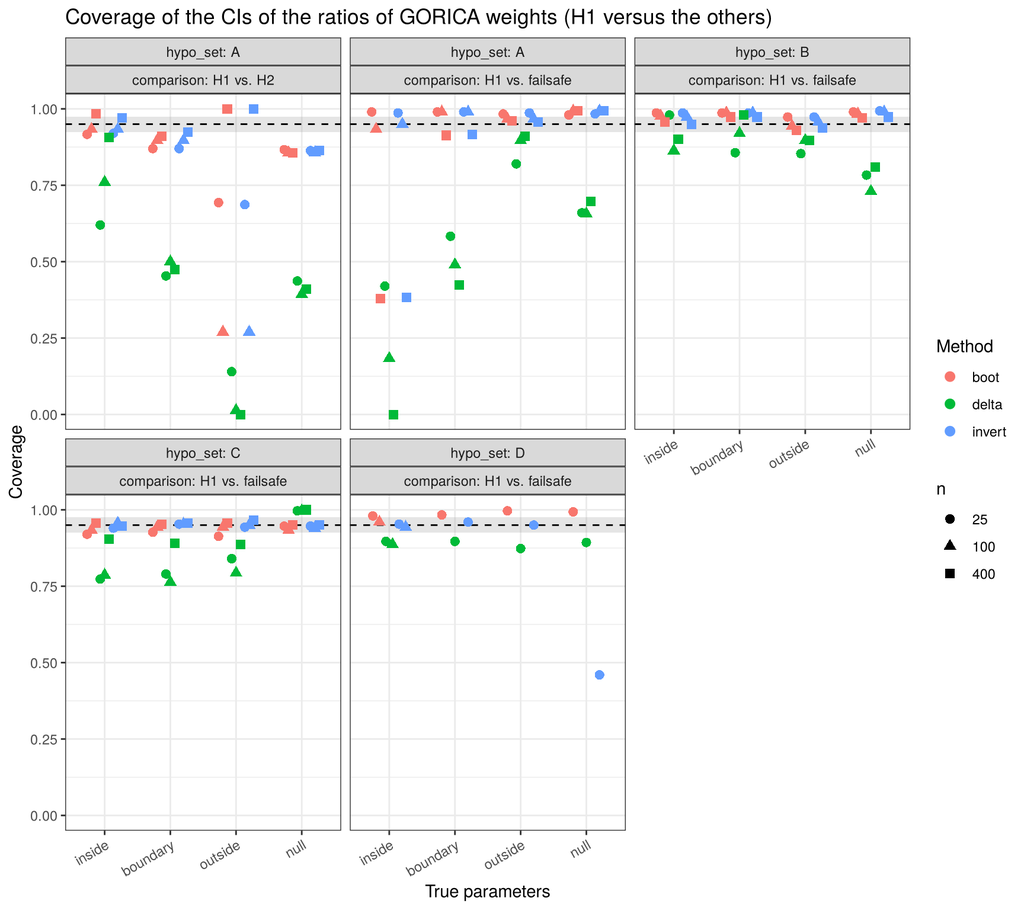

```r
plot_cov <- function(d, title) {
  ggplot(d, aes(x = theta, y = coverage, colour = method, shape = factor(n))) +
    annotate("rect", xmin = -Inf, xmax = Inf, ymin = .95 - 2 * mcse, ymax = .95 + 2 * mcse,
             alpha = .25, fill = "gray60") +
    geom_hline(yintercept = .95, linetype = "dashed") +
    geom_point(size = 2.5, position = position_dodge(width = .6)) +
    facet_wrap(~ hypo_set + comparison, labeller = label_both) +
    coord_cartesian(ylim = c(min(.5, min(d$coverage)), 1)) +
    labs(x = "True parameters", y = "Coverage", shape = "n", colour = "Method", title = title) +
    theme_bw() + theme(axis.text.x = element_text(angle = 30, hjust = 1))
}
plot_cov(subset(summ, quantity == "ratio"), "Coverage of the CIs of the ratios of GORICA weights (H1 versus the others)")
```

## 3.2 Differences in GORICA values

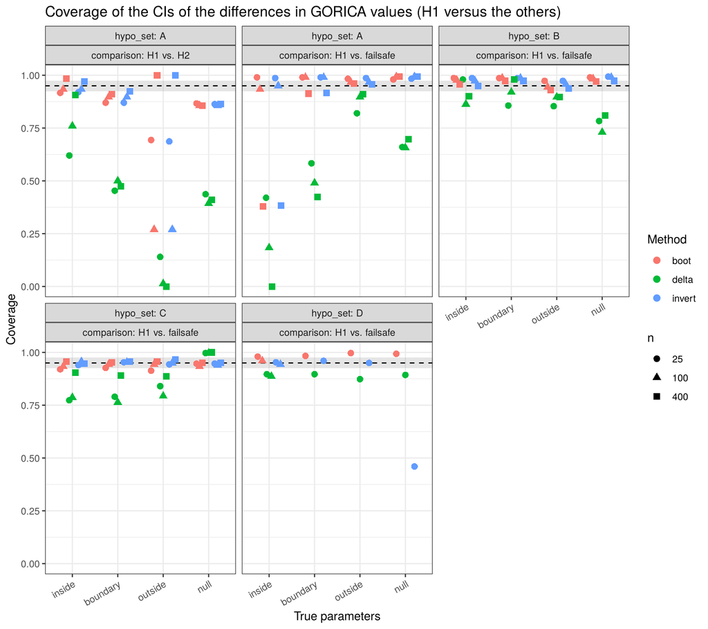

```r
plot_cov(subset(summ, quantity == "difference"), "Coverage of the CIs of the differences in GORICA values (H1 versus the others)")
```

## 3.3 GORICA weight of H1

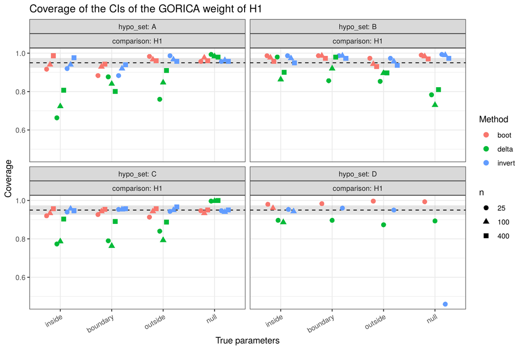

```r
plot_cov(subset(summ, quantity == "weight"), "Coverage of the CIs of the GORICA weight of H1")
```

## 3.4 GORICA value of H1

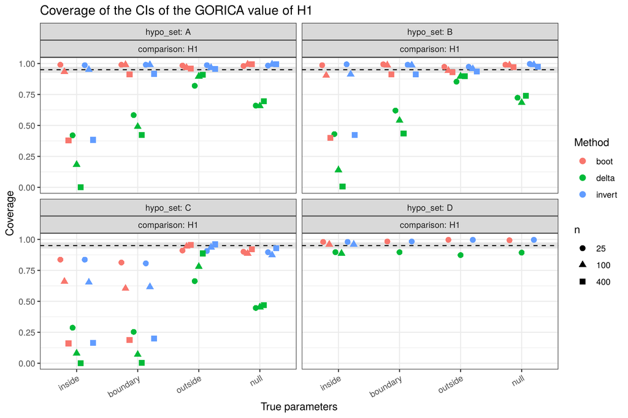

```r
plot_cov(subset(summ, quantity == "value"), "Coverage of the CIs of the GORICA value of H1")
```

## 3.5 Tables

```r
tab <- summ[order(summ$quantity, summ$hypo_set, summ$comparison, summ$theta, summ$n, summ$method), ]
num <- c("coverage", "missing", "inverted")
tab[num] <- lapply(tab[num], round, 3)
tab$median_width <- round(tab$median_width, 2)
knitr::kable(tab, row.names = FALSE)
```

| theta | n | hypo_set | method | quantity | comparison | coverage | missing | inverted | median_width |
| --- | --- | --- | --- | --- | --- | --- | --- | --- | --- |
| inside | 25 | A | boot | difference | H1 vs. H2 | 0.917 | 0.000 | 0 | 5.73 |
| inside | 25 | A | delta | difference | H1 vs. H2 | 0.620 | 0.283 | 0 | 8.08 |
| inside | 25 | A | invert | difference | H1 vs. H2 | 0.920 | 0.000 | 0 | 5.85 |
| inside | 100 | A | boot | difference | H1 vs. H2 | 0.933 | 0.000 | 0 | 10.97 |
| inside | 100 | A | delta | difference | H1 vs. H2 | 0.760 | 0.093 | 0 | 11.94 |
| inside | 100 | A | invert | difference | H1 vs. H2 | 0.933 | 0.000 | 0 | 10.88 |
| inside | 400 | A | boot | difference | H1 vs. H2 | 0.983 | 0.000 | 0 | 22.71 |
| inside | 400 | A | delta | difference | H1 vs. H2 | 0.907 | 0.000 | 0 | 23.02 |
| inside | 400 | A | invert | difference | H1 vs. H2 | 0.970 | 0.000 | 0 | 23.04 |
| boundary | 25 | A | boot | difference | H1 vs. H2 | 0.870 | 0.000 | 0 | 3.31 |
| boundary | 25 | A | delta | difference | H1 vs. H2 | 0.453 | 0.507 | 0 | 4.77 |
| boundary | 25 | A | invert | difference | H1 vs. H2 | 0.870 | 0.000 | 0 | 3.23 |
| boundary | 100 | A | boot | difference | H1 vs. H2 | 0.897 | 0.000 | 0 | 4.01 |
| boundary | 100 | A | delta | difference | H1 vs. H2 | 0.500 | 0.477 | 0 | 5.52 |
| boundary | 100 | A | invert | difference | H1 vs. H2 | 0.897 | 0.000 | 0 | 4.16 |
| boundary | 400 | A | boot | difference | H1 vs. H2 | 0.910 | 0.000 | 0 | 3.89 |
| boundary | 400 | A | delta | difference | H1 vs. H2 | 0.473 | 0.487 | 0 | 4.50 |
| boundary | 400 | A | invert | difference | H1 vs. H2 | 0.923 | 0.000 | 0 | 3.92 |
| outside | 25 | A | boot | difference | H1 vs. H2 | 0.693 | 0.000 | 0 | 0.46 |
| outside | 25 | A | delta | difference | H1 vs. H2 | 0.140 | 0.857 | 0 | 3.58 |
| outside | 25 | A | invert | difference | H1 vs. H2 | 0.687 | 0.000 | 0 | 0.47 |
| outside | 100 | A | boot | difference | H1 vs. H2 | 0.270 | 0.000 | 0 | 0.00 |
| outside | 100 | A | delta | difference | H1 vs. H2 | 0.013 | 0.987 | 0 | 0.55 |
| outside | 100 | A | invert | difference | H1 vs. H2 | 0.270 | 0.000 | 0 | 0.00 |
| outside | 400 | A | boot | difference | H1 vs. H2 | 1.000 | 0.000 | 0 | 0.00 |
| outside | 400 | A | delta | difference | H1 vs. H2 | 0.000 | 1.000 | 0 | NA |
| outside | 400 | A | invert | difference | H1 vs. H2 | 1.000 | 0.000 | 0 | 0.00 |
| null | 25 | A | boot | difference | H1 vs. H2 | 0.867 | 0.000 | 0 | 3.03 |
| null | 25 | A | delta | difference | H1 vs. H2 | 0.437 | 0.513 | 0 | 4.03 |
| null | 25 | A | invert | difference | H1 vs. H2 | 0.863 | 0.000 | 0 | 3.11 |

[output cut: 534 more lines]

## 3.6 Overall summary

```r
overall <- aggregate(cbind(coverage = covered, missing = missing) ~ method + quantity, data = res, FUN = mean)
overall$coverage <- round(overall$coverage, 3); overall$missing <- round(overall$missing, 3)
knitr::kable(overall)
```

| method | quantity | coverage | missing |
| --- | --- | --- | --- |
| boot | difference | 0.924 | 0.000 |
| delta | difference | 0.702 | 0.201 |
| invert | difference | 0.915 | 0.000 |
| boot | ratio | 0.924 | 0.000 |
| delta | ratio | 0.702 | 0.201 |
| invert | ratio | 0.915 | 0.000 |
| boot | value | 0.872 | 0.000 |
| delta | value | 0.550 | 0.000 |
| invert | value | 0.874 | 0.000 |
| boot | weight | 0.957 | 0.000 |
| delta | weight | 0.866 | 0.000 |
| invert | weight | 0.944 | 0.000 |

# 4 Diagnostics: degenerate CIs and the boundary of the parameter space

The coverage is evaluated strictly (the target value must lie in the CI). For the conditions with a (strict) coverage below .90, the CIs were recomputed while storing their bounds, to see whether the CIs miss the target or whether this is an artifact of the evaluation:

- when two hypotheses have the same order-restricted MLEs in (nearly) all samples (e.g., H1 and the unconstrained hypothesis when H1 clearly holds), the sampling distribution of their difference is (nearly) a point mass, and so is its CI; the expected value then differs from that point by a negligible amount, which a strict evaluation counts as non-coverage;
- for an equality-only hypothesis that is true (set D, all parameters equal), the noncentrality is on the boundary of its parameter space ($s = 0$); the lower bound of the inversion CI is then the expected difference at $s = 0$, which equals the target value, but is computed from $B$ draws, so that it lies above or below the target about half of the time.

Therefore, the coverage was also evaluated with a small tolerance (0.1 on the scale of the difference in GORICA values, i.e., about 5% on the scale of the ratio of weights), and the share of degenerate (point) CIs and of CIs above/below the target were recorded:

```r
# Diagnostics for the conditions with a (strict) coverage below .90 in the goric_CI() simulation:
# strict coverage, coverage with a small tolerance, and the share of degenerate (point) CIs.
suppressPackageStartupMessages(library(restriktor))
set.seed(4)
R <- 200; B <- 1000; tol <- 0.1   # tolerance on the scale of the difference in GORICA values
thetas <- list(inside = c(b1 = .4, b2 = .2, b3 = 0), boundary = c(b1 = .2, b2 = 0, b3 = 0),
               outside = c(b1 = 0, b2 = .2, b3 = .4), null = c(b1 = 0, b2 = 0, b3 = 0))
sets <- list(A = list(hypotheses = list(H1 = "b1 > b2 > b3", H2 = "b1 > b2 = b3"), comparison = "unconstrained"),
             C = list(hypotheses = list(H1 = "b1 > b2"), comparison = "complement"),
             D = list(hypotheses = list(H1 = "b1 = b2 = b3"), comparison = "unconstrained"))
cases <- data.frame(
  set      = c("A", "A", "A", "A", "A", "C", "C", "D"),
  theta    = c("boundary", "null", "outside", "inside", "inside", "boundary", "inside", "null"),
  n        = c(100, 100, 100, 400, 25, 100, 100, 25),
  quantity = c("H1 vs. H2", "H1 vs. H2", "H1 vs. H2", "H1 vs. failsafe", "H1 vs. failsafe",
               "value H1", "value H1", "H1 vs. failsafe"),
  method   = c("boot", "boot", "boot", "boot", "boot", "boot", "boot", "invert"),
  stringsAsFactors = FALSE)
out <- list()
for (i in seq_len(nrow(cases))) {
  cs <- cases[i, ]; hs <- sets[[cs$set]]; th <- thetas[[cs$theta]]; V <- diag(1 / cs$n, 3)
  g0 <- goric(th, VCOV = V, hypotheses = hs$hypotheses, comparison = hs$comparison)
  mods <- as.character(g0$result$model)
  EIC <- colMeans(restriktor:::goric_CI_boot(g0, mods, B = 2e5))
  k <- if (cs$quantity == "H1 vs. H2") 2 else length(mods)
  target <- if (cs$quantity == "value H1") EIC[1] else EIC[1] - EIC[k]
  b <- t(replicate(R, {
    g <- goric(th + rnorm(3, 0, sqrt(1 / cs$n)), VCOV = V, hypotheses = hs$hypotheses, comparison = hs$comparison)
    ci <- suppressMessages(goric_CI(g, method = cs$method, B = B))
    if (cs$quantity == "value H1") c(ci$IC$lower[1], ci$IC$upper[1])
    else { j <- which(ci$difference$model == mods[1] & ci$difference$vs == mods[k])
           c(ci$difference$lower[j], ci$difference$upper[j]) }
  }))
  out[[i]] <- cbind(cs, target = target,
                    strict = mean(b[, 1] <= target & target <= b[, 2]),
                    tolerant = mean(b[, 1] - tol <= target & target <= b[, 2] + tol),
                    degenerate = mean(b[, 2] - b[, 1] < 1e-6),
                    below = mean(target < b[, 1] - tol), above = mean(target > b[, 2] + tol))
  print(out[[i]], row.names = FALSE)
}
saveRDS(do.call(rbind, out), "diag_goric_CI.rds")
```

```r
knitr::kable(readRDS("diag_goric_CI.rds"), digits = 3, row.names = FALSE)
```

| set | theta | n | quantity | method | target | strict | tolerant | degenerate | below | above |
| --- | --- | --- | --- | --- | --- | --- | --- | --- | --- | --- |
| A | boundary | 100 | H1 vs. H2 | boot | 0.185 | 0.875 | 0.900 | 0.030 | 0.095 | 0.005 |
| A | null | 100 | H1 vs. H2 | boot | 0.331 | 0.855 | 0.900 | 0.050 | 0.095 | 0.005 |
| A | outside | 100 | H1 vs. H2 | boot | 0.665 | 0.305 | 1.000 | 0.685 | 0.000 | 0.000 |
| A | inside | 400 | H1 vs. failsafe | boot | -2.333 | 0.375 | 1.000 | 0.600 | 0.000 | 0.000 |
| A | inside | 25 | H1 vs. failsafe | boot | -2.046 | 0.985 | 0.985 | 0.000 | 0.010 | 0.005 |
| C | boundary | 100 | value H1 | boot | -3.274 | 0.605 | 1.000 | 0.310 | 0.000 | 0.000 |
| C | inside | 100 | value H1 | boot | -3.273 | 0.650 | 1.000 | 0.310 | 0.000 | 0.000 |
| D | null | 25 | H1 vs. failsafe | invert | -1.995 | 0.515 | 0.925 | 0.015 | 0.075 | 0.000 |

# 5 Conclusions

The coverages (ranges over all conditions) are:

- ratios of weights: inversion 0.270 to 1.000; bootstrap 0.270 to 1.000; delta method 0.000 to 1.000;
- differences in GORICA values: inversion 0.270 to 1.000; bootstrap 0.270 to 1.000; delta method 0.000 to 1.000;
- weight of H1: inversion 0.460 to 0.993; bootstrap 0.883 to 0.997; delta method 0.663 to 1.000;
- GORICA value of H1: bootstrap 0.160 to 0.997; delta method 0.000 to 0.910.

**Inversion (`method = "invert"`, the default).** Where the inversion applies (sets C and D), it gives the best coverage: .94 to .97 for H1 versus its complement with one inequality restriction (set C), and .94 to .96 for an equality-only hypothesis versus the unconstrained hypothesis (set D), except when that hypothesis is true: the strict coverage is then about .5, but this is the boundary artifact described above (with a tolerance: .93 to .96). For the other pairs, the inversion method uses the bootstrap, so its results equal those of the bootstrap.

**Delta method (`method = "delta"`).** The delta method undercovers in most conditions (overall .70 for the ratios), because the differences in GORICA values are not normally distributed when hypotheses overlap or the parameters are near the boundaries; it should only be used for clearly distinguishable hypotheses in large samples, as stated in `?goric_CI`.

**Single GORICA values.** The CIs of a single GORICA value are of less interest (only relative values matter), and their strict coverage is low in some conditions, but this is (mostly) the degenerate-CI artifact (with a tolerance: 1).

**Recommendations.**

- Keep `method = "invert"` as the default.
- In `goric_CI_invert()`, use the exact expected difference at the boundary when the lower limit of the noncentrality is $s = 0$ for an equality-only hypothesis (namely, the number of equality restrictions plus penalty_factor $\times$ the difference in penalties), instead of the Monte Carlo estimate; this removes the boundary artifact.
- Mention in `?goric_CI` that, for two order-restricted hypotheses that overlap at a boundary, the bootstrap CI can be somewhat too narrow (coverage about .90) when the parameters are near that boundary.

# 6 Session information

```r
sim$sessionInfo
```